# Analyses Update

```r
library(tidyverse)
library(ggridges)
library(lubridate)
library(scales)
library(corrplot)
library(factoextra)
library(roll)
library(RolWinMulCor)
library(BINCOR)
library(corrr)
library(patchwork)
library(MetBrewer)
dat = read_csv("Data/analysis_ready/final_combined_dates_filled_v1.csv")
dat$sampledate = as.Date(paste0(dat$year-1, "-12-31")) + dat$daynum_fill
```

## Data Info / Status

- Southern lakes run from 1996 - 2018
- Northern lakes from 1982 - 2018
- Lake-years with missing data have been filled:

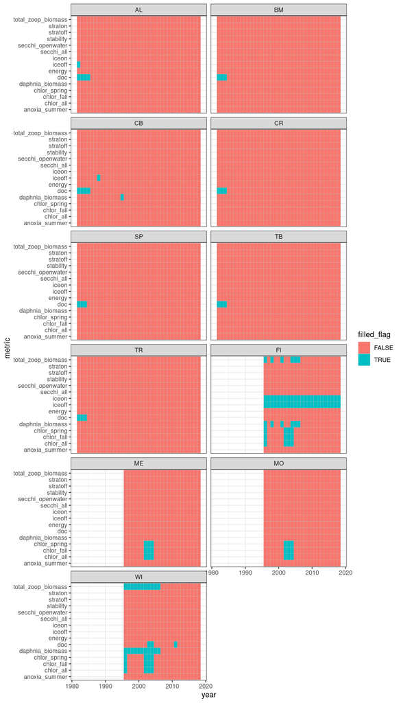

```r
dat %>%
  mutate(lakeid = factor(lakeid, levels =  c("AL", "BM", "CB", "CR", "SP", "TB", "TR", "FI", "ME", "MO", "WI"))) %>%
  ggplot(aes(year, metric, fill=filled_flag)) +
  geom_tile(color="grey") +
  theme_bw() +
  facet_wrap(~lakeid, nrow=6)
```

### How variables were filled

- iceoff/iceon: FI filled with MO; northern lakes filled w/ lake-specific model of other northern lake ice on or off dates
- doc: filled with lake-specific model (daynum_doc ~ daynum_all_other_variables)
- chl: filled with values from old/unpublished files on LTER server; concentrations were incorrect but assuming relative values comparable
- total zoop and daphnia biomass: filled with lake-specific median daynum

## Distribution of peak dates

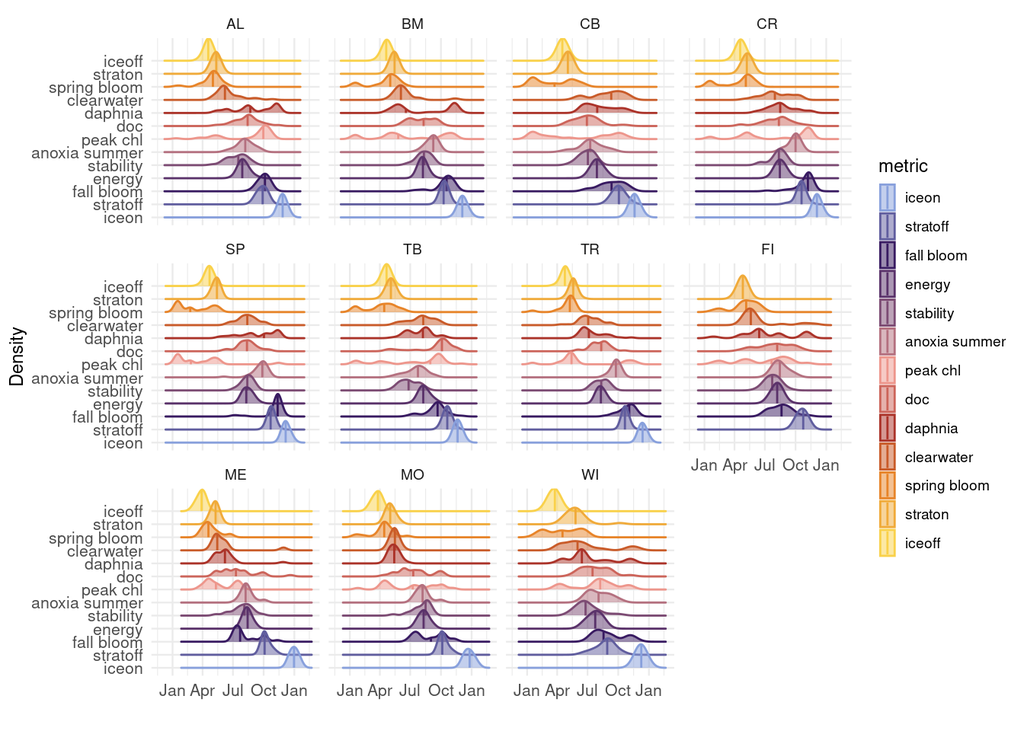

```r
lakes_order = c("AL", "BM", "CB", "CR", "SP", "TB", "TR", "FI", "ME", "MO", "WI")

vars_order = c("iceoff", "straton", "chlor_spring", "secchi_openwater", "daphnia_biomass", "doc", "chlor_all", "anoxia_summer", "stability", "energy", "chlor_fall", "stratoff", "iceon")

dat %>%
  filter(metric %in% vars_order) %>%
  mutate(lakeid = factor(lakeid, levels = lakes_order),
         metric = factor(metric, levels = rev(vars_order), labels = rev(c("iceoff", "straton", "spring bloom", "clearwater", "daphnia", "doc",  "peak chl", "anoxia summer", "stability", "energy", "fall bloom", "stratoff", "iceon")))) %>%
  ggplot() +
  stat_density_ridges(aes(x = as.Date(daynum, origin = as.Date('2019-01-01')),
                          y= metric, col = metric, fill = metric),
                      alpha = 0.5, quantile_lines = T, quantiles = 2) +
  scale_fill_manual(values=met.brewer("Archambault", 13)) +
  scale_color_manual(values=met.brewer("Archambault", 13)) +
  scale_x_date(labels = date_format("%b")) +
  facet_wrap(~ (lakeid)) +
  xlab('') + ylab('Density')+
  theme_minimal(base_size = 9) +
  theme(axis.text = element_text(size=8),
        legend.key.height = unit(0.5,"cm"),
        legend.key.width = unit(0.3,"cm"))
```

## Correlation matrices

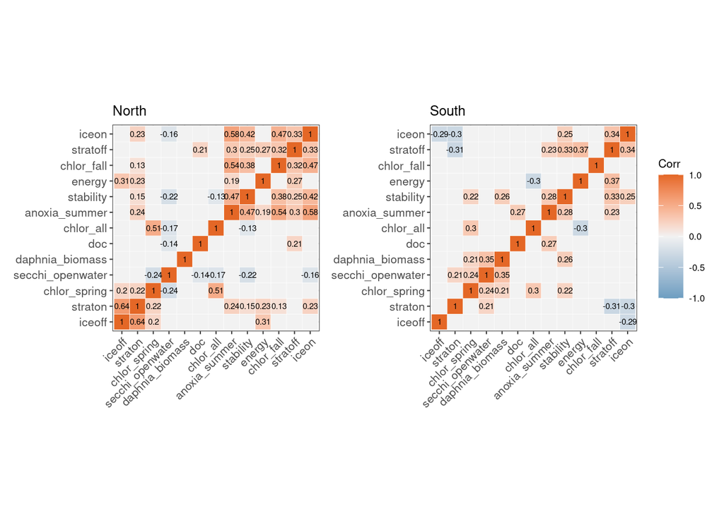

```r
source(file = 'src/Functions/plotCorrplot.R')

dat = read_csv("Data/analysis_ready/final_combined_dates_filled_v1.csv") |>
  mutate(sampledate =  as.Date(paste0(year-1, "-12-31")) + daynum_fill) |>
  mutate(lakeid = factor(lakeid, levels =  c("AL", "BM", "CB", "CR", "SP", "TB", "TR", "FI", "ME", "MO", "WI")))

lakes_order = c("AL", "BM", "CB", "CR", "SP", "TB", "TR", "FI", "ME", "MO", "WI")
vars_order = c("iceoff", "straton", "chlor_spring", "secchi_openwater", "daphnia_biomass", "doc", "chlor_all", "anoxia_summer", "stability", "energy", "chlor_fall", "stratoff", "iceon")

dat2 = dat %>%
  filter(metric %in% vars_order) %>%
  select(lakeid, year, metric, daynum_fill) |>
  pivot_wider(names_from = metric, values_from = daynum_fill) |>
  mutate(group = if_else(lakeid %in% c("AL", "BM", "CB", "CR", "SP", "TB", "TR"), 'North','South')) |>
  select(-lakeid, -year) |>
  relocate(vars_order)

###### Compute a correlation matrix ######
# p1 = plotCorrplot(dat2 |> select(-group)) + labs(title = 'All')
p2 = plotCorrplot(dat2 |> filter(group == 'North') |> select(-group)) + labs(title = 'North')
p3 = plotCorrplot(dat2 |> filter(group == 'South') |> select(-group)) + labs(title = 'South')
# p1 + p2 + p3 + guide_area() + plot_layout(guides = 'collect')
p2 + p3 + plot_layout(guides = 'collect')
```

# Analyses

## Eigenvalue Analysis

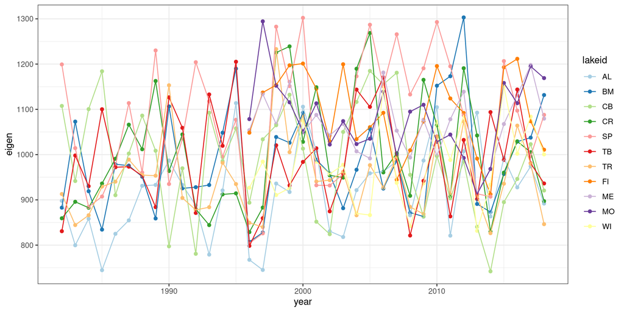

```r
source("src/Functions/timing_matrix_construction.R")

vars_order_eigen =  c("iceoff", "straton", "secchi_openwater", "daphnia_biomass", "doc", "chlor_spring", "anoxia_summer", "stability", "energy", "stratoff", "iceon")
all_var_combos = expand.grid(vars_order_eigen, vars_order_eigen)
all_lake_years = dat %>%
  filter(metric %in% vars_order_eigen) %>%
  select(lakeid, year) %>%
  distinct() %>%
  rename(id = lakeid)

all_lyv = expand_grid(all_var_combos, all_lake_years)

all_lyv_1 = dat %>%
  filter(metric %in% vars_order_eigen) %>%
  select(lakeid, year, metric, daynum_fill) %>%
  rename(Var1 = metric, id=lakeid, value=daynum_fill) %>%
  right_join(all_lyv) %>%
  rename(Value1 = value)

all_lyv_2 = dat %>%
  filter(metric %in% vars_order) %>%
  select(lakeid, year, metric, daynum_fill) %>%
  rename(Var2 = metric, id=lakeid, value=daynum_fill) %>%
  right_join(all_lyv_1) %>%
  rename(Value2 = value) %>%
  select(id, year, Var1, Value1, Var2, Value2) %>%
  mutate(doy_diff = Value2 - Value1)

lake_years = dat %>%
  select(lakeid, year) %>%
  distinct()

lake_years$eigen = as.numeric(NA)

lakes = unique(lake_years$lakeid)
for(l in lakes){
  hold_mats = matrix_single_lake(timings.df = all_lyv_2, single_lake = l)
  for(i in 1:length(dimnames(hold_mats)[[3]])){
    cur_year = dimnames(hold_mats)[[3]][i]
    cur_ind = lake_years$lakeid == l & lake_years$year == as.numeric(cur_year)
    x = abs(hold_mats[,,i])
    error <- try(eigen(x), silent = T)
    if (class(error) != "try-error"){
      lake_years[cur_ind, "eigen"] = max(error$values)
    }
  }
}

ggplot(lake_years %>% arrange(year)) +
  geom_point(aes(year, eigen, col=lakeid, group=lakeid)) +
  geom_line(aes(year, eigen, col=lakeid, group=lakeid)) +
  scale_color_brewer(palette = "Paired") +
  theme_bw()
```

#### Correlation of eigenvalues

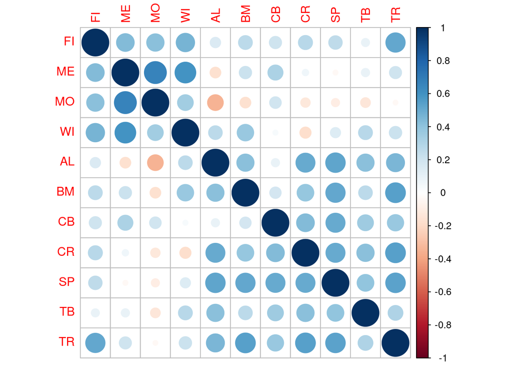

```r
eigen_corrs = lake_years %>%
  pivot_wider(names_from = lakeid, values_from = eigen) %>%
  select(-year) %>%
  cor(use="complete.obs")
# diag(eigen_corrs) = 0

eigen_corrs %>%
  corrplot(method="circle")
```

## PCA

**Setup** select lakes and variables to analyze:

```r
var_pca = c("iceoff", "straton", "secchi_openwater", "dapnia_biomass", "doc", "chlor_spring", "anoxia_summer", "stability", "energy", "stratoff", "iceon")
lakeid_pca = c("FI", "ME", "MO", "WI", "AL", "BM", "CB", "CR", "SP", "TB", "TR")

dat_pca = dat %>%
  filter(metric %in% var_pca & lakeid %in% lakeid_pca) %>%
  select(lakeid, year, metric, daynum_fill) %>%
  pivot_wider(names_from = "metric", values_from="daynum_fill")
```

Do the PCA, plot results:

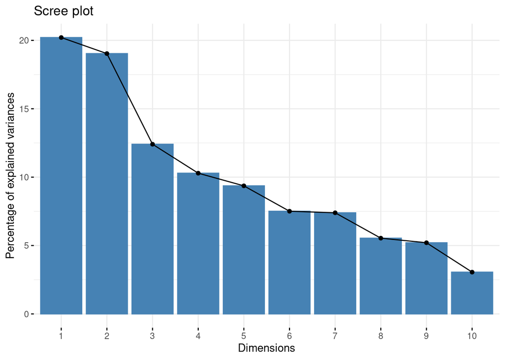

```r
pca = prcomp(dat_pca[, 3:ncol(dat_pca)], scale=T, center=T)

fviz_eig(pca)
```

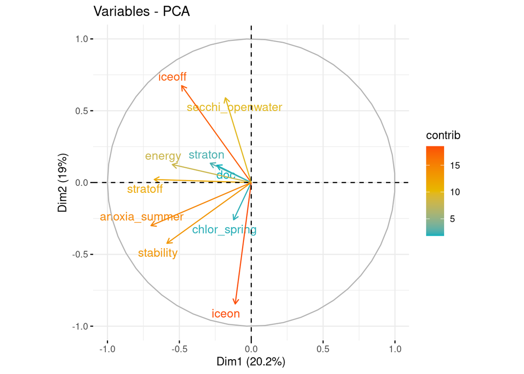

```r
fviz_pca_var(pca,
             col.var = "contrib", # Color by contributions to the PC
             gradient.cols = c("#00AFBB", "#E7B800", "#FC4E07"),
             repel = TRUE     # Avoid text overlapping
)
```

### Principal components correlation analysis

```r
var = get_pca_var(pca)
inds = get_pca_ind(pca)

pca_res = dat_pca[, c("lakeid", "year")]
pca_res$PC1 = pca$x[,1]
pca_res$PC2 = pca$x[,2]
pca_res$PC3 = pca$x[,3]
pca_res$PC4 = pca$x[,4]

pca_res_cor = pca_res %>%
  pivot_longer(cols = c("PC1", "PC2", "PC3", "PC4")) %>%
  pivot_wider(names_from = "lakeid", values_from="value") %>%
  arrange(name, year)


pca_matrix_p1 = pca_res_cor %>%
  filter(name == "PC1") %>%
  select(-year) %>%
  summarise(as.data.frame(cor(.[,lakeid_pca], use="complete.obs"))) %>%
  as.matrix()
rownames(pca_matrix_p1) = lakeid_pca
# diag(pca_matrix) = 0

pca_matrix_p2 = pca_res_cor %>%
  filter(name == "PC2") %>%
  select(-year) %>%
  summarise(as.data.frame(cor(.[,lakeid_pca], use="complete.obs"))) %>%
  as.matrix()
rownames(pca_matrix_p2) = lakeid_pca
# diag(pca_matrix) = 0
```

### Plot first two PC correlations

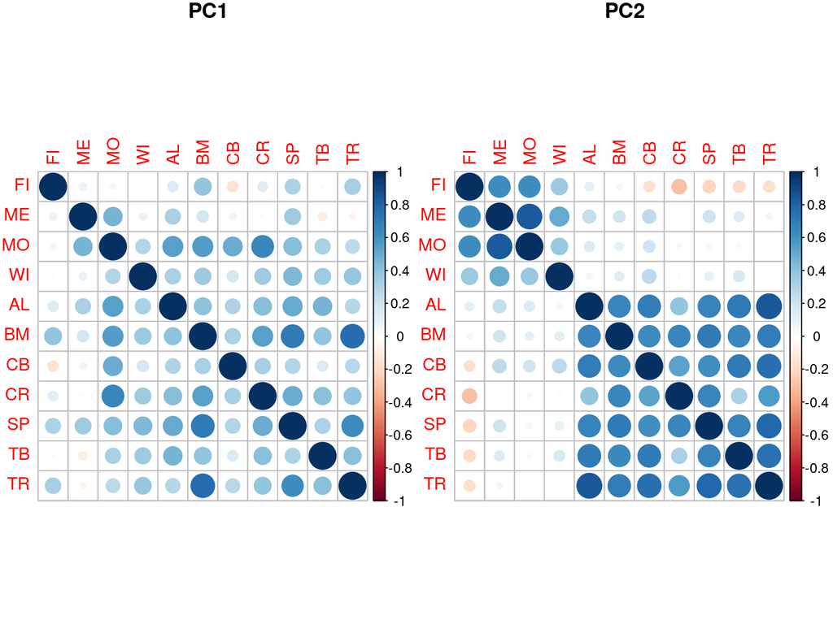

```r
# dev.off()
par(mfrow=c(1,2))
corrplot(pca_matrix_p1, method="circle", title="PC1", mar=c(0,0,1,0))
corrplot(pca_matrix_p2, method="circle", title = "PC2", mar=c(0,0,1,0))
```

### PCA without ice dates

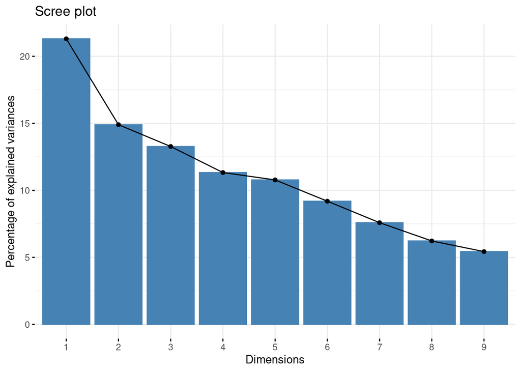

```r
var_pca_noice = c("straton", "secchi_openwater", "daphnia_biomass", "doc", "chlor_spring", "anoxia_summer", "stability", "energy", "stratoff")
lakeid_pca = c("FI", "ME", "MO", "WI", "AL", "BM", "CB", "CR", "SP", "TB", "TR")

dat_pca_noice = dat %>%
  filter(metric %in% var_pca_noice & lakeid %in% lakeid_pca) %>%
  select(lakeid, year, metric, daynum_fill) %>%
  pivot_wider(names_from = "metric", values_from="daynum_fill")

pca_noice = prcomp(dat_pca_noice[, 3:ncol(dat_pca_noice)], scale=T, center=T)

fviz_eig(pca_noice)
```

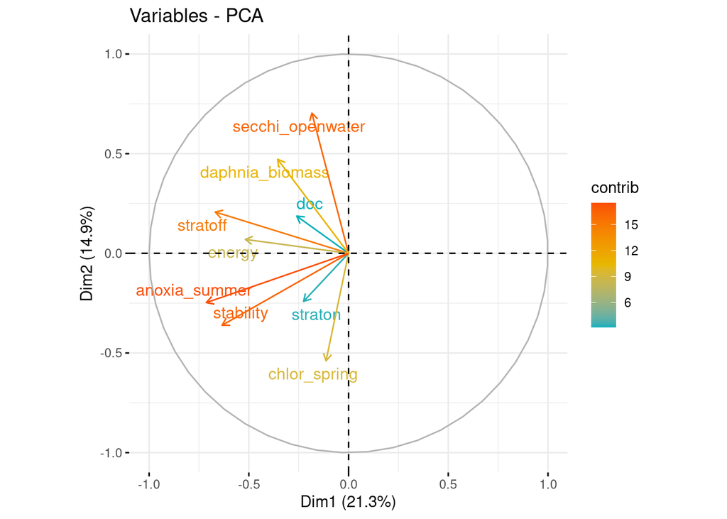

```r
fviz_pca_var(pca_noice,
             col.var = "contrib", # Color by contributions to the PC
             gradient.cols = c("#00AFBB", "#E7B800", "#FC4E07"),
             repel = TRUE     # Avoid text overlapping
)
```

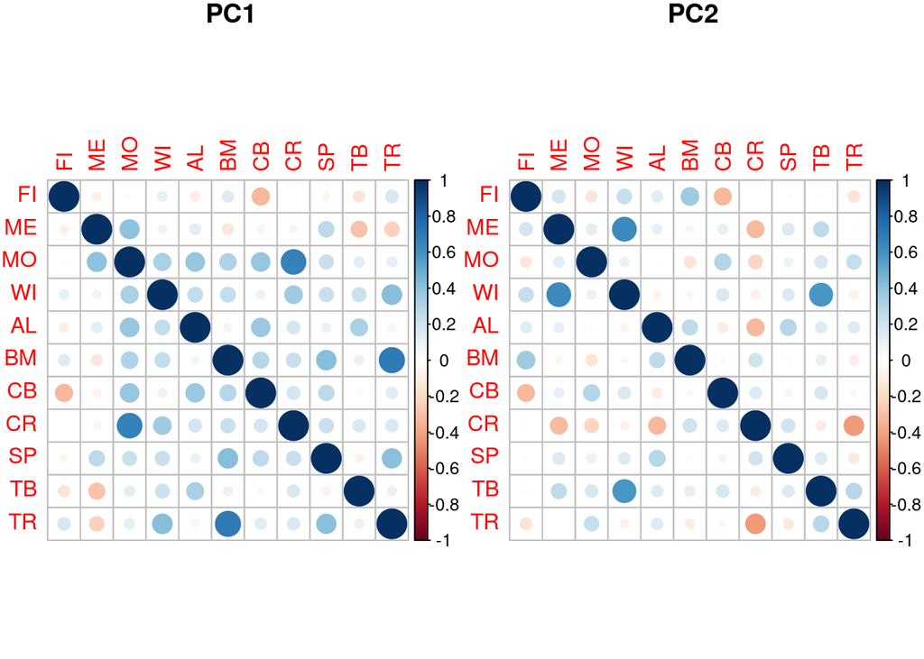

```r
var = get_pca_var(pca_noice)
inds = get_pca_ind(pca_noice)

pca_res_noice = dat_pca_noice[, c("lakeid", "year")]
pca_res_noice$PC1 = pca_noice$x[,1]
pca_res_noice$PC2 = pca_noice$x[,2]
pca_res_noice$PC3 = pca_noice$x[,3]
pca_res_noice$PC4 = pca_noice$x[,4]

pca_res_cor_noice = pca_res_noice %>%
  pivot_longer(cols = c("PC1", "PC2", "PC3", "PC4")) %>%
  pivot_wider(names_from = "lakeid", values_from="value") %>%
  arrange(name, year)


pca_matrix_p1_noice = pca_res_cor_noice %>%
  filter(name == "PC1") %>%
  select(-year) %>%
  summarise(as.data.frame(cor(.[,lakeid_pca], use="complete.obs"))) %>%
  as.matrix()
rownames(pca_matrix_p1_noice) = lakeid_pca
# diag(pca_matrix) = 0

pca_matrix_p2_noice = pca_res_cor_noice %>%
  filter(name == "PC2") %>%
  select(-year) %>%
  summarise(as.data.frame(cor(.[,lakeid_pca], use="complete.obs"))) %>%
  as.matrix()
rownames(pca_matrix_p2_noice) = lakeid_pca

par(mfrow=c(1,2))
corrplot(pca_matrix_p1_noice, method="circle", title="PC1", mar=c(0,0,1,0))
corrplot(pca_matrix_p2_noice, method="circle", title = "PC2", mar=c(0,0,1,0))
```

### PCA north vs. south separate

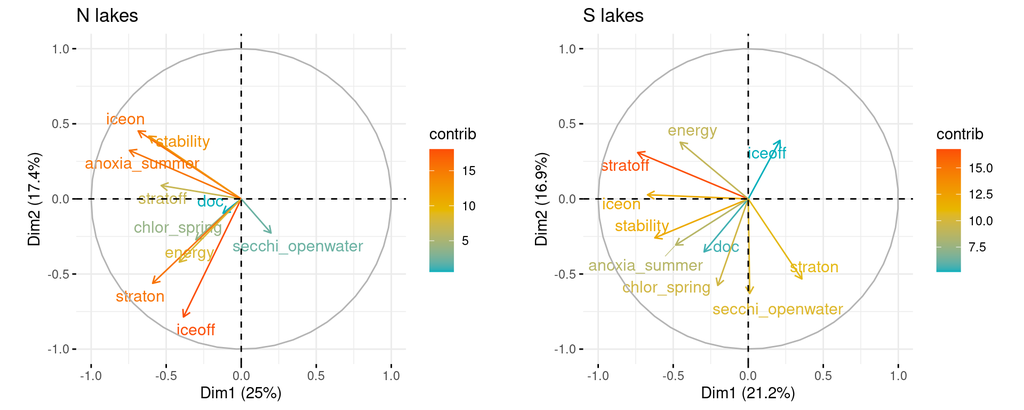

```r
dat_pca_N = dat %>%
  filter(metric %in% var_pca & lakeid %in% c("AL", "BM", "CB", "CR", "SP", "TB", "TR")) %>%
  select(lakeid, year, metric, daynum_fill) %>%
  pivot_wider(names_from = "metric", values_from="daynum_fill")

dat_pca_S = dat %>%
  filter(metric %in% var_pca & lakeid %in% c("FI", "ME", "MO", "WI")) %>%
  select(lakeid, year, metric, daynum_fill) %>%
  pivot_wider(names_from = "metric", values_from="daynum_fill")

pca_N = prcomp(dat_pca_N[, 3:ncol(dat_pca_N)], scale=T, center=T)
pca_S = prcomp(dat_pca_S[, 3:ncol(dat_pca_S)], scale=T, center=T)

# fviz_eig(pca_noice)
pca_plot_N = fviz_pca_var(pca_N,
             col.var = "contrib", # Color by contributions to the PC
             gradient.cols = c("#00AFBB", "#E7B800", "#FC4E07"),
             repel = TRUE,
             title ="N lakes")    # Avoid text overlapping
pca_plot_S = fviz_pca_var(pca_S,
             col.var = "contrib", # Color by contributions to the PC
             gradient.cols = c("#00AFBB", "#E7B800", "#FC4E07"),
             repel = TRUE,
             title ="S lakes")

gridExtra::grid.arrange(pca_plot_N, pca_plot_S, nrow=1)
```

## Correlation analysis

### All lakes

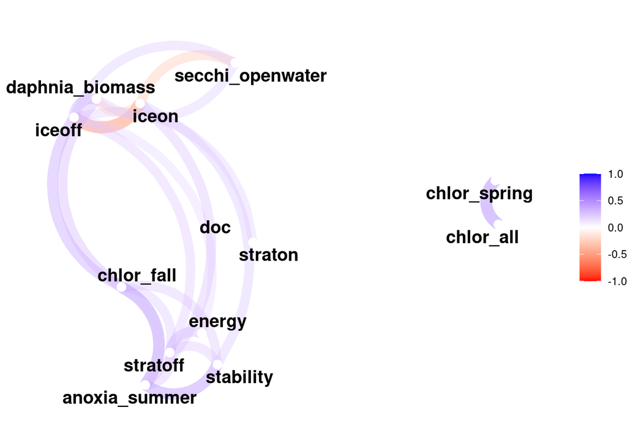

```r
cor_vars = vars_order

dat %>%
  filter(metric %in% cor_vars) %>%
  select(lakeid, year, metric, daynum_fill) %>%
  pivot_wider(names_from = metric, values_from = daynum_fill) %>%
  select(-lakeid, -year) %>%
  correlate() %>%
  network_plot(min_cor = 0.2, colours = c("red", "white", "blue"))
```

### North vs. South

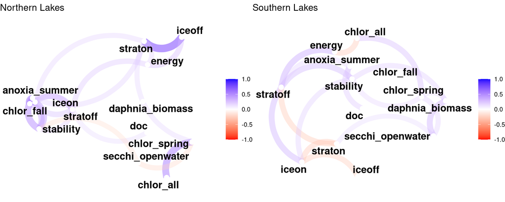

```r
cor_vars = vars_order
# "AL", "BM", "CB", "CR", "SP", "TB", "TR", "FI", "ME", "MO", "WI"
pN = dat %>%
  filter(metric %in% cor_vars & lakeid %in% c("AL", "BM", "CB", "CR", "SP", "TB", "TR")) %>%
  select(lakeid, year, metric, daynum_fill) %>%
  pivot_wider(names_from = metric, values_from = daynum_fill) %>%
  select(-lakeid, -year) %>%
  correlate() %>%
  network_plot(min_cor = 0.2, colours = c("red", "white", "blue")) +
  ggtitle("Northern Lakes")


pS = dat %>%
  filter(metric %in% cor_vars & lakeid %in% c("FI", "ME", "MO", "WI")) %>%
  select(lakeid, year, metric, daynum_fill) %>%
  pivot_wider(names_from = metric, values_from = daynum_fill) %>%
  select(-lakeid, -year) %>%
  correlate() %>%
  network_plot(min_cor = 0.2, colours = c("red", "white", "blue")) +
  ggtitle("Southern Lakes")

gridExtra::grid.arrange(pN, pS, nrow=1)
```

(I’m missing code for the rolling window correlation analysis Kait did)

## Current Takeaways

1. Physical events have the most consistent “phenology” across years.
2. For chemical and biolgical events, eutrophic lakes adhere most strongly to tradition PEG model.
3. Across all lakes and variables, ice cover explains similarity in phenological event timing and separates the lakes into groups geographically. (*any better word than “explains”?*)
4. Ignoring/limiting the effect of ice cover, physical events are still the largest contributor to variation in phenology, but there is some evidence for differences the importance of trophic status and geographical controls (note that these variables are confounded in our dataset).

## TODO

1. Get FI/MO/WI “bad” chlorophyll data files from Mark, use to fill peak chlorophyll dates
2. Network connectivity inference analysis
3. Other analyses?
4. Dive into literature
5. Finalize figures
6. JASM talk
7. Write manuscript